# Assumptions of Linear Regression

Econometrics - ECON 426

## Introduction

## Slide

In this tutorial, we will analyze the classical assumptions of linear regression.

## What makes OLS BLUE

## Classical assumptions of linear regression

1. The dependent variable is **linearly** related to the coefficients of the model and the model is correctly specified. \[{y_i} = {\beta _1} + {\beta _2}{x_{i2}} + \cdots + {\beta _K}{x_{iK}} + {e_i},\;\;i = 1, \ldots ,N\]
2. No perfect **multicollinearity.** No independent variable has a perfect linear relationship with any of the other independent variables.
3. The **mean** of the **error** term is **zero.**\[E({y_i}) = {\beta _1} + {\beta _2}{x_{i2}} + \cdots + {\beta _K}{x_{iK}} \Leftrightarrow E({e_i}) = 0\]
4. The error term has a **constant variance.** No heteroscedasticity.\[{\mathop{\rm var}} ({y_i}) = {\mathop{\rm var}} ({e_i}) = {\sigma ^2}\]
5. The error term is **normally distributed.** (Not absolutely necessary)\[{y_i}~N\left[ {({\beta _1} + {\beta _2}{x_{i2}} + \cdots + {\beta _K}{x_{iK}}),\;{\sigma ^2}} \right] \Leftrightarrow {e_i}~N(0,{\sigma ^2})\]
6. The error terms are **uncorrelated** with each other. No autocorrelation or serial correlation. \[{\mathop{\rm cov}} ({y_i},{y_j}) = {\mathop{\rm cov}} ({e_i},{e_j}) = 0\]
7. The **independent variable(s)** is/are **uncorrelated** with the equation **error term.**

## Two assumptions about the explanatory variables

1. The explanatory variables are not random variables
   - We are assuming that the values of the explanatory variables are known to us prior to our observing the values of the dependent variable
2. Any one of the explanatory variables is not an exact linear function of the others (More on this latter)
   - This assumption is equivalent to assuming that no variable is redundant
   - If this assumption is violated, then \(x'x\) is less than full rank and thus it is not inevitable.

## Big Andy’s Hamburger Sales

## Data

```r
library(POE5Rdata)
data(andy)
datatable(head(andy))
```

|  | sales | price | advert |
| --- | --- | --- | --- |
| 1 | 73.2 | 5.69 | 1.3 |
| 2 | 71.8 | 6.49 | 2.9 |
| 3 | 62.4 | 5.63 | 0.8 |
| 4 | 67.4 | 6.22 | 0.7 |
| 5 | 89.3 | 5.02 | 1.5 |
| 6 | 70.3 | 6.41 | 1.3 |

## The basic *andy* model

```r
mod1 <- lm(sales~price+advert, data=andy)
(smod1 <- summ(mod1))
```

| Observations | 75 |
| --- | --- |
| Dependent variable | sales |
| Type | OLS linear regression |

| F(2,72) | 29.25 |
| --- | --- |
| R² | 0.45 |
| Adj. R² | 0.43 |

|  | Est. | S.E. | t val. | p |
| --- | --- | --- | --- | --- |
| (Intercept) | 118.91 | 6.35 | 18.72 | 0.00 |
| price | -7.91 | 1.10 | -7.22 | 0.00 |
| advert | 1.86 | 0.68 | 2.73 | 0.01 |

Standard errors: OLS

## A closer look at the data

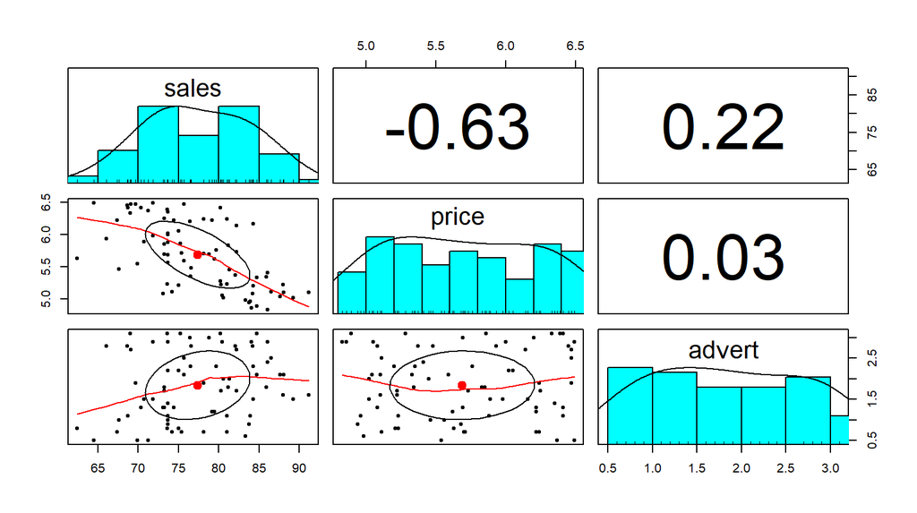

```r
psych::pairs.panels(andy)
```

## Residual vs. Fit Plot

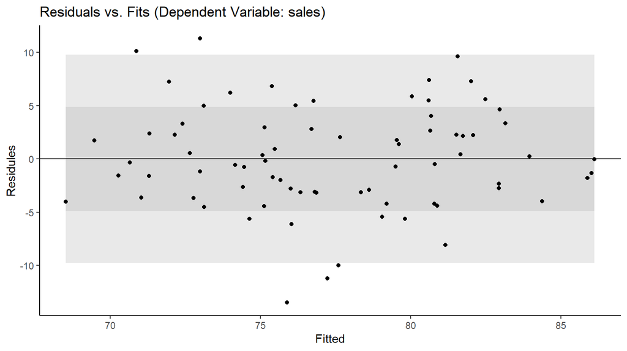

```r
plot.fitted(mod1)
```

## The quadratic *andy* model

```r
mod2 <- lm(sales~price+advert+I(advert^2), data=andy)
(smod2 <- summ(mod2))
```

| Observations | 75 |
| --- | --- |
| Dependent variable | sales |
| Type | OLS linear regression |

| F(3,71) | 24.46 |
| --- | --- |
| R² | 0.51 |
| Adj. R² | 0.49 |

|  | Est. | S.E. | t val. | p |
| --- | --- | --- | --- | --- |
| (Intercept) | 109.72 | 6.80 | 16.14 | 0.00 |
| price | -7.64 | 1.05 | -7.30 | 0.00 |
| advert | 12.15 | 3.56 | 3.42 | 0.00 |
| I(advert^2) | -2.77 | 0.94 | -2.94 | 0.00 |

Standard errors: OLS

## Residual vs. Fit Plot

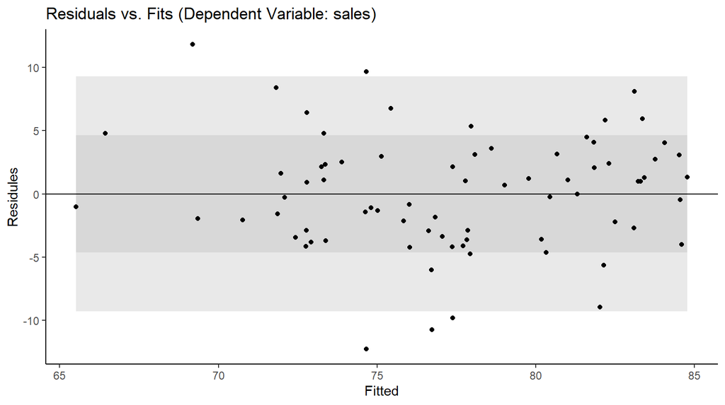

```r
plot.fitted(mod2)
```

## You did it!